# simon-5502-05-slides

2025-02-18

## Topics to be covered

- What you will learn
  - Mathematical model of interactions
  - Interactions in multi-factor analysis of variance
  - Interactions in analysis of covariance
  - Interactions in multiple linear regression

## Mathematical model, 1

- $Y_{ijk}=\mu+\alpha_i+\beta_j+(\alpha \beta)_{ij}+\epsilon_{ijk}$
  - i=1,…,a j=1,…,b, k=1,…,n
- If 1 is the reference category
  - $\alpha_1=0$
  - $\beta_1=0$
  - $(\alpha \beta)_{1j}=0$
  - $(\alpha \beta)_{i1}=0$

## Mathematical model, 2

- $SS_A=\Sigma_i nb(\bar{Y}_{i..}-\bar{Y}_{...})^2$
- $SS_B=\Sigma_i na(\bar{Y}_{.j.}-\bar{Y}_{...})^2$
- $SS_{AB}=\Sigma_i \Sigma_j n(\bar{Y}_{ij.}-\bar{Y}_{i..}-\bar{Y}_{.j.}+ \bar{Y}_{ij.})^2$
- $SS_E=\Sigma_i \Sigma_j \Sigma_k (Y_{ijk}-\bar{Y}_{ij.})^2$
- $SS_T=\Sigma_i \Sigma_j \Sigma_k (Y_{ijk}-\bar{Y}_{...})^2$

## Test for an interaction

- $SS_{AB}$ has (a-1)(b-1) degrees of freedom
- $SS_E$ has ab(n-1) degrees of freedom
- Accept $H_0$ if $F=\frac{MS_{AB}}{MS_E}$ is close to one
  - In R, fit a model without an interaction
  - Compare to a model with interaction
  - Using the anova function

## Break #1

- What you have learned
  - Mathematical model of interactions
- What’s coming next
  - Interactions in multi-factor analysis of variance

## Hypothetical applications

- Study with two drugs and two placebos
- Four treatment options
  - Placebo plus placebo
  - Drug A plus placebo
  - Placebo plus Drug B
  - Drug A plus Drug B

## Listing of hypothetical data

```
# A tibble: 8 × 3
  a     b         y
  <fct> <fct> <dbl>
1 P     P       0.9
2 P     P       1.1
3 A     P       2.9
4 A     P       3.1
5 P     B       3.9
6 P     B       4.1
7 A     B       9.9
8 A     B      10.1
```

## Line plot of hypothetical data, 1

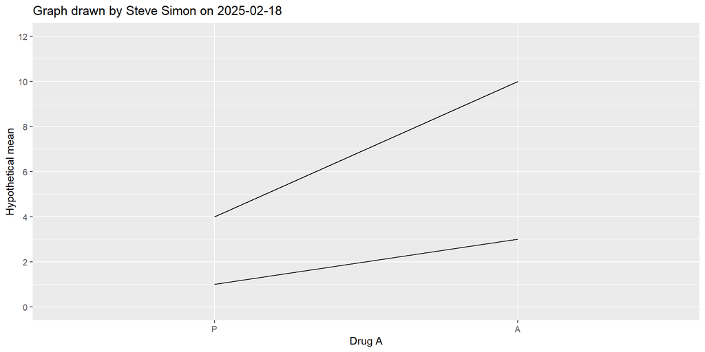

## Create indicator variables

```
# A tibble: 8 × 6
  a     b       i_a   i_b  i_ab     y
  <fct> <fct> <dbl> <dbl> <dbl> <dbl>
1 P     P         0     0     0   0.9
2 P     P         0     0     0   1.1
3 A     P         1     0     0   2.9
4 A     P         1     0     0   3.1
5 P     B         0     1     0   3.9
6 P     B         0     1     0   4.1
7 A     B         1     1     1   9.9
8 A     B         1     1     1  10.1
```

## Interaction model, 1

- `lm(y=a+b+a:b, data=hyp)`
- `lm(y=a*b, data=hyp)`
- `lm(y=i_a+i_b+i_ab, data=hyp_1)`

```
# A tibble: 4 × 2
  term        estimate
  <chr>          <dbl>
1 (Intercept)     1.00
2 i_a             2
3 i_b             3
4 i_ab            4
```

## Interaction model, 2

- (Intercept): estimated average effort of two placebos
- i_a: estimated average change due to drug A alone
- i_b: estimated average change due to drug B alone
- i_ab: estimated synergistic effect of both drugs

## Interaction model, 3

- `P P mean = 1`
- `A P mean = 1 + 2`
- `P B mean = 1 + 3`
- `A B mean = 1 + 2 + 3 + 4`

## Line plot of hypothetical data, 2

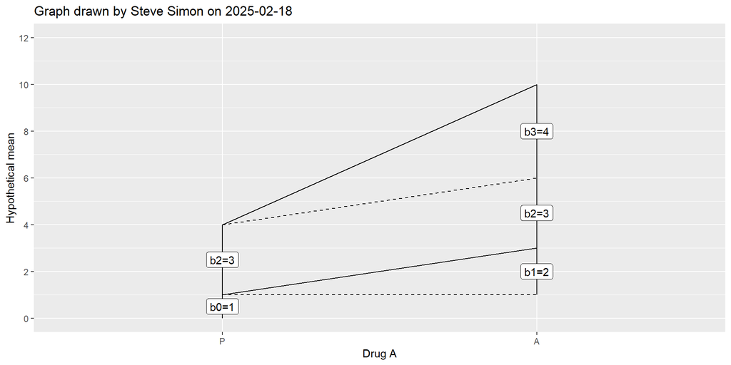

## Line plot of hypothetical data, 3

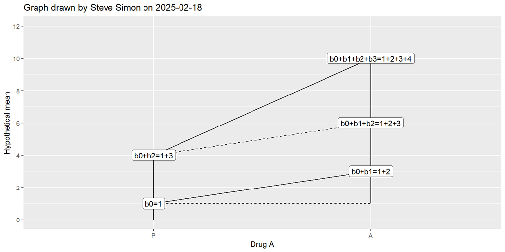

## Study of three exercise programs

- Swimming
- Jogging
- Reading (control)

## Descriptive statistics for exercise program

```
# A tibble: 3 × 2
  prog     pct
  <fct>    <glue>
1 Reading  33% (300/900)
2 Jogging  33% (300/900)
3 Swimming 33% (300/900)
```

## Descriptive statistics for hours

```
# A tibble: 1 × 4
  hours_mean hours_sd hours_min hours_max
       <dbl>    <dbl>     <dbl>     <dbl>
1       2.00    0.495     0.175      4.07
```

## Descriptive statistics for gender

```
# A tibble: 2 × 2
  gender pct
  <fct>  <glue>
1 Male   50% (450/900)
2 Female 50% (450/900)
```

## Descriptive statistics for effort

- 0 = no effort, 50=maximum effort

```
# A tibble: 1 × 4
  effort_mean effort_sd effort_min effort_max
        <dbl>     <dbl>      <dbl>      <dbl>
1        29.7      5.14       12.9       44.1
```

## Descriptive statistics for loss

- A negative value is a weight gain

```
# A tibble: 1 × 4
  loss_mean loss_sd loss_min loss_max
      <dbl>   <dbl>    <dbl>    <dbl>
1      10.0    14.1    -17.1     54.2
```

## Line plot, weight loss by program and gender

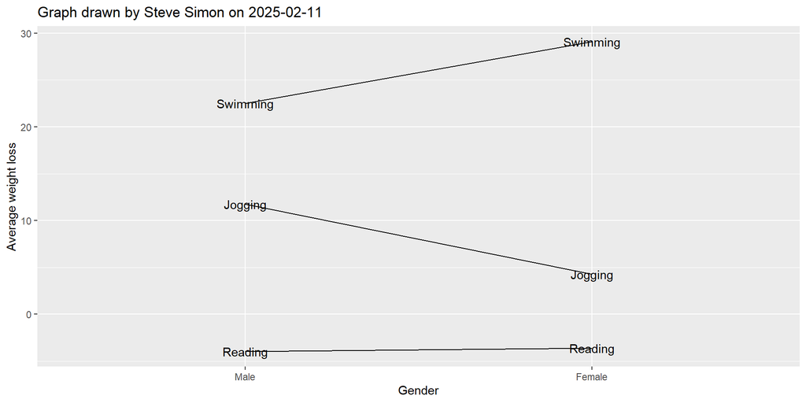

## Interaction model

- Reference categories: male and reading

```
# A tibble: 6 × 5
  term                      estimate std.error statistic p.value
  <chr>                        <dbl>     <dbl>     <dbl> <glue>
1 (Intercept)                 -3.96      0.532    -7.43  p < 0.001
2 genderFemale                 0.335     0.753     0.446 p = 0.656
3 progJogging                 15.7       0.753    20.9   p < 0.001
4 progSwimming                26.5       0.753    35.2   p < 0.001
5 genderFemale:progJogging    -7.82      1.06     -7.35  p < 0.001
6 genderFemale:progSwimming    6.26      1.06      5.88  p < 0.001
```

## Live demo, Interactions in multi-factor analysis of variance

## Break #2

- What you have learned
  - Interactions in multi-factor analysis of variance
- What’s coming next
  - Interactions in analysis of covariance

## Interactions in analysis of covariance, 1

- Center your continuous covariate

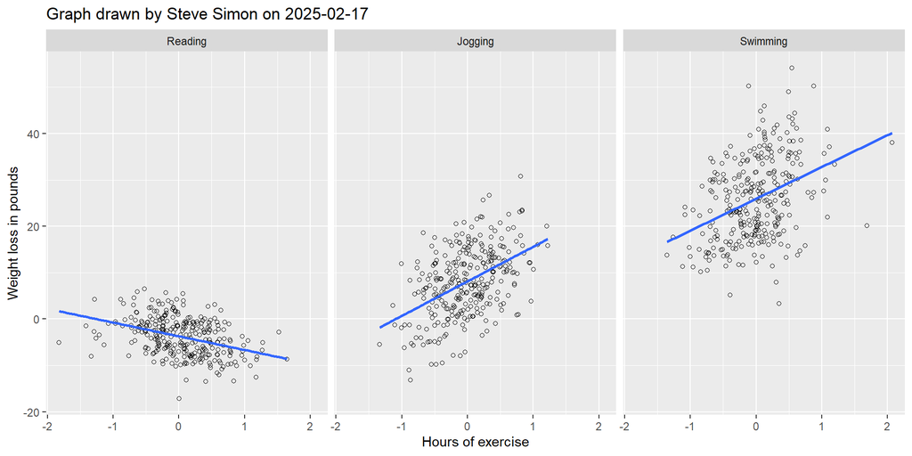

## Interactions in analysis of covariance, 2

- Center your continuous covariate

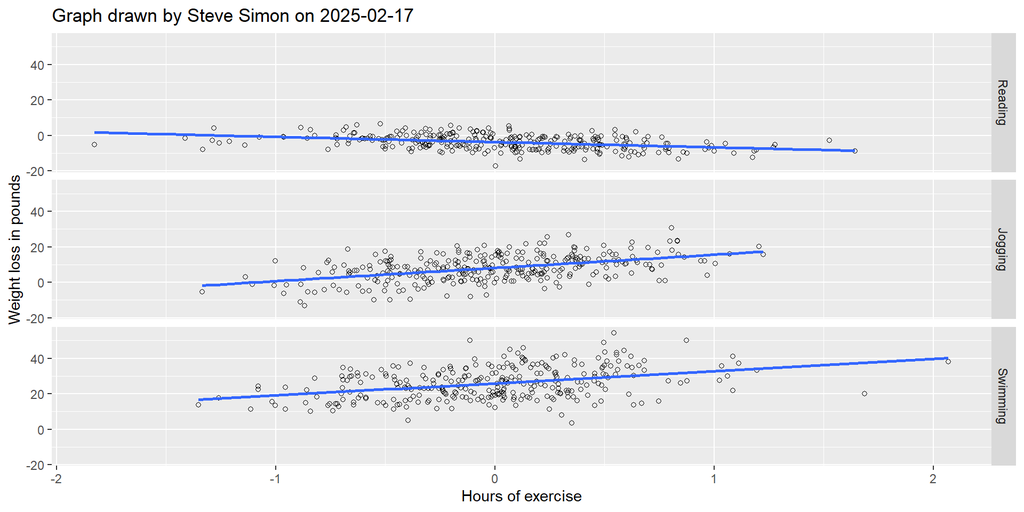

## Live demo, Interactions in analysis of covariance

## Break #3

- What you have learned
  - Interactions in analysis of covariance
- What’s coming next
  - Interactions in multiple linear regression

## Interactions in multiple linear regression

- Center your continuous predictors

```
# A tibble: 4 × 5
  term         estimate std.error statistic p.value
  <chr>           <dbl>     <dbl>     <dbl> <glue>
1 (Intercept)    16.8      0.436      38.6  p < 0.001
2 hours           6.87     0.926       7.42 p < 0.001
3 effort          0.890    0.0855     10.4  p < 0.001
4 hours:effort    0.373    0.187       2.00 p = 0.046
```

## Summary

- What you have learned
  - Mathematical model of interactions
  - Interactions in multi-factor analysis of variance
  - Interactions in analysis of covariance
  - Interactions in multiple linear regression